# Prosper Loan Dataset Exploration

## Introduction

> Prosper Loan dataset contains 113,937 loans with 81 variables on each loan, including loan amount, borrower rate (or interest rate), current loan status, borrower income, and many others. I Focused my exploration on about 10-15 variables out of 81 variables in the dataset for easy and proper exploration of the dataset. So, there were needs for droping some of the variable in the dataset. My exploration was focused on predicting factors that affect loan’s Borrower APR.

## Preliminary Wrangling

```python
# import all packages and set plots to be embedded inline
import numpy as np
import pandas as pd
import matplotlib.pyplot as plt
import seaborn as sb

%matplotlib inline
```

```python
#Loadin prosperLoanData.csv dataset into a pandas dataframe
PLoan_df = pd.read_csv('prosperLoanData.csv')
```

## Data Assessment

### Visual Assessment

Visual assessment of the dataset was done using microsoft excel. the dataset was assessed and some quality issues and tidiness were notice and documented.

### Assessing data programatically

```python
#checking the dataset structure
PLoan_df.head(5)
```

|  | ListingKey | ListingNumber | ListingCreationDate | CreditGrade | Term | LoanStatus | ClosedDate | BorrowerAPR | BorrowerRate | LenderYield | ... | LP_ServiceFees | LP_CollectionFees | LP_GrossPrincipalLoss | LP_NetPrincipalLoss | LP_NonPrincipalRecoverypayments | PercentFunded | Recommendations | InvestmentFromFriendsCount | InvestmentFromFriendsAmount | Investors |
| --- | --- | --- | --- | --- | --- | --- | --- | --- | --- | --- | --- | --- | --- | --- | --- | --- | --- | --- | --- | --- | --- |
| 0 | 1021339766868145413AB3B | 193129 | 2007-08-26 19:09:29.263000000 | C | 36 | Completed | 2009-08-14 00:00:00 | 0.16516 | 0.1580 | 0.1380 | ... | -133.18 | 0.0 | 0.0 | 0.0 | 0.0 | 1.0 | 0 | 0 | 0.0 | 258 |
| 1 | 10273602499503308B223C1 | 1209647 | 2014-02-27 08:28:07.900000000 | NaN | 36 | Current | NaN | 0.12016 | 0.0920 | 0.0820 | ... | 0.00 | 0.0 | 0.0 | 0.0 | 0.0 | 1.0 | 0 | 0 | 0.0 | 1 |
| 2 | 0EE9337825851032864889A | 81716 | 2007-01-05 15:00:47.090000000 | HR | 36 | Completed | 2009-12-17 00:00:00 | 0.28269 | 0.2750 | 0.2400 | ... | -24.20 | 0.0 | 0.0 | 0.0 | 0.0 | 1.0 | 0 | 0 | 0.0 | 41 |
| 3 | 0EF5356002482715299901A | 658116 | 2012-10-22 11:02:35.010000000 | NaN | 36 | Current | NaN | 0.12528 | 0.0974 | 0.0874 | ... | -108.01 | 0.0 | 0.0 | 0.0 | 0.0 | 1.0 | 0 | 0 | 0.0 | 158 |
| 4 | 0F023589499656230C5E3E2 | 909464 | 2013-09-14 18:38:39.097000000 | NaN | 36 | Current | NaN | 0.24614 | 0.2085 | 0.1985 | ... | -60.27 | 0.0 | 0.0 | 0.0 | 0.0 | 1.0 | 0 | 0 | 0.0 | 20 |

5 rows × 81 columns

```python
#Shape of the dataset
PLoan_df.shape
```

```
(113937, 81)
```

```python
PLoan_df.info()
```

```
<class 'pandas.core.frame.DataFrame'>
RangeIndex: 113937 entries, 0 to 113936
Data columns (total 81 columns):
ListingKey                             113937 non-null object
ListingNumber                          113937 non-null int64
ListingCreationDate                    113937 non-null object
CreditGrade                            28953 non-null object
Term                                   113937 non-null int64
LoanStatus                             113937 non-null object
ClosedDate                             55089 non-null object
BorrowerAPR                            113912 non-null float64
BorrowerRate                           113937 non-null float64
LenderYield                            113937 non-null float64
EstimatedEffectiveYield                84853 non-null float64
EstimatedLoss                          84853 non-null float64
EstimatedReturn                        84853 non-null float64
ProsperRating (numeric)                84853 non-null float64
ProsperRating (Alpha)                  84853 non-null object
ProsperScore                           84853 non-null float64
ListingCategory (numeric)              113937 non-null int64
BorrowerState                          108422 non-null object
Occupation                             110349 non-null object
EmploymentStatus                       111682 non-null object
EmploymentStatusDuration               106312 non-null float64
IsBorrowerHomeowner                    113937 non-null bool
CurrentlyInGroup                       113937 non-null bool
GroupKey                               13341 non-null object
DateCreditPulled                       113937 non-null object
CreditScoreRangeLower                  113346 non-null float64
CreditScoreRangeUpper                  113346 non-null float64
FirstRecordedCreditLine                113240 non-null object
CurrentCreditLines                     106333 non-null float64
OpenCreditLines                        106333 non-null float64
TotalCreditLinespast7years             113240 non-null float64
OpenRevolvingAccounts                  113937 non-null int64
OpenRevolvingMonthlyPayment            113937 non-null float64
InquiriesLast6Months                   113240 non-null float64
TotalInquiries                         112778 non-null float64
CurrentDelinquencies                   113240 non-null float64
AmountDelinquent                       106315 non-null float64
```

[output cut: 31 more lines]

```
LP_CustomerPayments                    113937 non-null float64
LP_CustomerPrincipalPayments           113937 non-null float64
LP_InterestandFees                     113937 non-null float64
LP_ServiceFees                         113937 non-null float64
LP_CollectionFees                      113937 non-null float64
LP_GrossPrincipalLoss                  113937 non-null float64
LP_NetPrincipalLoss                    113937 non-null float64
LP_NonPrincipalRecoverypayments        113937 non-null float64
PercentFunded                          113937 non-null float64
Recommendations                        113937 non-null int64
InvestmentFromFriendsCount             113937 non-null int64
InvestmentFromFriendsAmount            113937 non-null float64
Investors                              113937 non-null int64
dtypes: bool(3), float64(50), int64(11), object(17)
memory usage: 68.1+ MB
```

```python
PLoan_df.describe()
```

|  | ListingNumber | Term | BorrowerAPR | BorrowerRate | LenderYield | EstimatedEffectiveYield | EstimatedLoss | EstimatedReturn | ProsperRating (numeric) | ProsperScore | ... | LP_ServiceFees | LP_CollectionFees | LP_GrossPrincipalLoss | LP_NetPrincipalLoss | LP_NonPrincipalRecoverypayments | PercentFunded | Recommendations | InvestmentFromFriendsCount | InvestmentFromFriendsAmount | Investors |
| --- | --- | --- | --- | --- | --- | --- | --- | --- | --- | --- | --- | --- | --- | --- | --- | --- | --- | --- | --- | --- | --- |
| count | 1.139370e+05 | 113937.000000 | 113912.000000 | 113937.000000 | 113937.000000 | 84853.000000 | 84853.000000 | 84853.000000 | 84853.000000 | 84853.000000 | ... | 113937.000000 | 113937.000000 | 113937.000000 | 113937.000000 | 113937.000000 | 113937.000000 | 113937.000000 | 113937.000000 | 113937.000000 | 113937.000000 |
| mean | 6.278857e+05 | 40.830248 | 0.218828 | 0.192764 | 0.182701 | 0.168661 | 0.080306 | 0.096068 | 4.072243 | 5.950067 | ... | -54.725641 | -14.242698 | 700.446342 | 681.420499 | 25.142686 | 0.998584 | 0.048027 | 0.023460 | 16.550751 | 80.475228 |
| std | 3.280762e+05 | 10.436212 | 0.080364 | 0.074818 | 0.074516 | 0.068467 | 0.046764 | 0.030403 | 1.673227 | 2.376501 | ... | 60.675425 | 109.232758 | 2388.513831 | 2357.167068 | 275.657937 | 0.017919 | 0.332353 | 0.232412 | 294.545422 | 103.239020 |
| min | 4.000000e+00 | 12.000000 | 0.006530 | 0.000000 | -0.010000 | -0.182700 | 0.004900 | -0.182700 | 1.000000 | 1.000000 | ... | -664.870000 | -9274.750000 | -94.200000 | -954.550000 | 0.000000 | 0.700000 | 0.000000 | 0.000000 | 0.000000 | 1.000000 |
| 25% | 4.009190e+05 | 36.000000 | 0.156290 | 0.134000 | 0.124200 | 0.115670 | 0.042400 | 0.074080 | 3.000000 | 4.000000 | ... | -73.180000 | 0.000000 | 0.000000 | 0.000000 | 0.000000 | 1.000000 | 0.000000 | 0.000000 | 0.000000 | 2.000000 |
| 50% | 6.005540e+05 | 36.000000 | 0.209760 | 0.184000 | 0.173000 | 0.161500 | 0.072400 | 0.091700 | 4.000000 | 6.000000 | ... | -34.440000 | 0.000000 | 0.000000 | 0.000000 | 0.000000 | 1.000000 | 0.000000 | 0.000000 | 0.000000 | 44.000000 |
| 75% | 8.926340e+05 | 36.000000 | 0.283810 | 0.250000 | 0.240000 | 0.224300 | 0.112000 | 0.116600 | 5.000000 | 8.000000 | ... | -13.920000 | 0.000000 | 0.000000 | 0.000000 | 0.000000 | 1.000000 | 0.000000 | 0.000000 | 0.000000 | 115.000000 |
| max | 1.255725e+06 | 60.000000 | 0.512290 | 0.497500 | 0.492500 | 0.319900 | 0.366000 | 0.283700 | 7.000000 | 11.000000 | ... | 32.060000 | 0.000000 | 25000.000000 | 25000.000000 | 21117.900000 | 1.012500 | 39.000000 | 33.000000 | 25000.000000 | 1189.000000 |

8 rows × 61 columns

```python
#checking for duplicate in the dataset
sum(PLoan_df.duplicated())
```

```
0
```

```python
#accessing nullvalue vaiables
PLoan_df[PLoan_df['BorrowerAPR'].isnull()]
```

|  | ListingKey | ListingNumber | ListingCreationDate | CreditGrade | Term | LoanStatus | ClosedDate | BorrowerAPR | BorrowerRate | LenderYield | ... | LP_ServiceFees | LP_CollectionFees | LP_GrossPrincipalLoss | LP_NetPrincipalLoss | LP_NonPrincipalRecoverypayments | PercentFunded | Recommendations | InvestmentFromFriendsCount | InvestmentFromFriendsAmount | Investors |
| --- | --- | --- | --- | --- | --- | --- | --- | --- | --- | --- | --- | --- | --- | --- | --- | --- | --- | --- | --- | --- | --- |
| 2543 | 044B3365298516680DA929B | 36 | 2005-11-28 22:42:42.557000000 | HR | 36 | Completed | 2006-01-06 00:00:00 | NaN | 0.10000 | 0.0950 | ... | -4.02 | 0.0000 | 0.0 | 0.0 | 0.0 | 1.000 | 0 | 0 | 0.0 | 5 |
| 14632 | E4103364750435927B6F892 | 67 | 2006-01-06 12:54:51.887000000 | AA | 36 | Completed | 2006-04-10 00:00:00 | NaN | 0.06500 | 0.0550 | ... | -2.59 | 0.0000 | 0.0 | 0.0 | 0.0 | 1.000 | 0 | 0 | 0.0 | 5 |
| 25166 | B3083364738592238DBDA63 | 6 | 2005-11-15 16:06:47.457000000 | AA | 36 | Completed | 2005-11-29 00:00:00 | NaN | 0.04350 | 0.0385 | ... | -0.42 | 0.0000 | 0.0 | 0.0 | 0.0 | 1.000 | 0 | 0 | 0.0 | 3 |
| 25330 | B6C33364979883097BBCD77 | 39 | 2005-11-29 13:29:16.810000000 | AA | 36 | Completed | 2006-03-21 00:00:00 | NaN | 0.06395 | 0.0552 | ... | -1.30 | 0.0000 | 0.0 | 0.0 | 0.0 | 1.000 | 0 | 0 | 0.0 | 4 |
| 29773 | 3480336511078238810A782 | 21 | 2005-11-18 14:48:19.753000000 | AA | 36 | Completed | 2008-06-05 00:00:00 | NaN | 0.06000 | 0.0550 | ... | -16.08 | 0.0000 | 0.0 | 0.0 | 0.0 | 1.000 | 0 | 0 | 0.0 | 10 |
| 39870 | B6E73366056348939D8801F | 24 | 2005-11-20 14:45:55.193000000 | C | 36 | Completed | 2006-10-24 00:00:00 | NaN | 0.12000 | 0.1150 | ... | -53.96 | 0.0000 | 0.0 | 0.0 | 0.0 | 1.000 | 0 | 0 | 0.0 | 6 |
| 43587 | 2F123364529418907A58D4C | 19 | 2005-11-18 14:16:59.093000000 | AA | 36 | Completed | 2005-11-29 00:00:00 | NaN | 0.08500 | 0.0750 | ... | -1.10 | 0.0000 | 0.0 | 0.0 | 0.0 | 1.000 | 0 | 0 | 0.0 | 6 |
| 62297 | 2F25336514614362295DA03 | 7 | 2005-11-15 18:25:56.107000000 | E | 36 | Completed | 2005-11-30 00:00:00 | NaN | 0.17000 | 0.1150 | ... | -0.42 | 0.0000 | 0.0 | 0.0 | 0.0 | 1.000 | 0 | 0 | 0.0 | 1 |
| 71280 | DED033645500376547AF34E | 60 | 2005-12-29 19:53:41 | C | 36 | Completed | 2008-04-21 00:00:00 | NaN | 0.09000 | 0.0850 | ... | -74.98 | 0.0000 | 0.0 | 0.0 | 0.0 | 1.000 | 0 | 0 | 0.0 | 8 |
| 71875 | F50A33647261871547E3E0D | 68 | 2006-01-06 13:05:50.890000000 | AA | 36 | Completed | 2006-07-11 00:00:00 | NaN | 0.07000 | 0.0650 | ... | -6.01 | 0.0000 | 0.0 | 0.0 | 0.0 | 1.000 | 0 | 0 | 0.0 | 1 |
| 73945 | 8D5F33655433257693D8033 | 18 | 2005-11-18 14:10:50.470000000 | HR | 36 | Completed | 2006-01-06 00:00:00 | NaN | 0.25000 | 0.2450 | ... | -2.08 | 0.0000 | 0.0 | 0.0 | 0.0 | 1.000 | 0 | 0 | 0.0 | 1 |
| 74114 | 0B4133652604109810CAA3B | 34 | 2005-11-28 16:16:35.077000000 | AA | 36 | Completed | 2008-12-08 00:00:00 | NaN | 0.06000 | 0.0550 | ... | -7.61 | 0.0000 | 0.0 | 0.0 | 0.0 | 1.000 | 0 | 0 | 0.0 | 7 |
| 75710 | F7C53365521712881842072 | 25 | 2005-11-20 20:15:47.240000000 | C | 36 | Completed | 2005-11-30 00:00:00 | NaN | 0.10000 | 0.0750 | ... | -0.88 | 0.0000 | 0.0 | 0.0 | 0.0 | 1.000 | 0 | 0 | 0.0 | 3 |
| 78414 | 468C3366438848688B8B5B4 | 22 | 2005-11-18 16:35:48.210000000 | AA | 36 | Completed | 2006-01-09 00:00:00 | NaN | 0.13000 | 0.1250 | ... | -1.68 | 0.0000 | 0.0 | 0.0 | 0.0 | 1.000 | 0 | 0 | 0.0 | 2 |
| 80369 | 54A833661083301426FFC90 | 44 | 2005-12-03 14:03:22.207000000 | AA | 36 | Completed | 2006-01-06 00:00:00 | NaN | 0.06500 | 0.0550 | ... | -1.12 | 0.0000 | 0.0 | 0.0 | 0.0 | 1.000 | 0 | 0 | 0.0 | 10 |
| 81848 | 584D3364403680278BB6704 | 28 | 2005-11-21 19:35:46.890000000 | D | 36 | Completed | 2008-03-18 00:00:00 | NaN | 0.13000 | 0.0950 | ... | -25.67 | -123.3229 | 0.0 | 0.0 | 0.0 | 1.000 | 0 | 0 | 0.0 | 4 |
| 90598 | B87F3364623805558A45EAB | 16 | 2005-11-18 13:39:03.263000000 | B | 36 | Completed | 2005-11-29 00:00:00 | NaN | 0.12000 | 0.1150 | ... | -0.33 | 0.0000 | 0.0 | 0.0 | 0.0 | 1.000 | 0 | 0 | 0.0 | 4 |
| 92516 | 80373365765621932269C34 | 48 | 2005-12-05 13:58:06.017000000 | AA | 36 | Completed | 2008-07-06 00:00:00 | NaN | 0.07000 | 0.0650 | ... | -23.12 | 0.0000 | 0.0 | 0.0 | 0.0 | 1.000 | 0 | 0 | 0.0 | 5 |
| 103509 | 0E0F336443449038617E9F4 | 59 | 2005-12-21 19:37:33.813000000 | A | 36 | Completed | 2008-12-30 00:00:00 | NaN | 0.09450 | 0.0845 | ... | -69.17 | 0.0000 | 0.0 | 0.0 | 0.0 | 1.011 | 0 | 0 | 0.0 | 14 |
| 105925 | B01233643651103736EE3B6 | 20 | 2005-11-18 14:22:34.763000000 | AA | 36 | Completed | 2005-12-28 00:00:00 | NaN | 0.08500 | 0.0750 | ... | -2.38 | 0.0000 | 0.0 | 0.0 | 0.0 | 1.000 | 0 | 0 | 0.0 | 6 |
| 106465 | B8D63366141679436131B1C | 23 | 2005-11-20 13:21:31.993000000 | NC | 36 | Completed | 2006-01-06 00:00:00 | NaN | 0.09000 | 0.0850 | ... | -4.00 | 0.0000 | 0.0 | 0.0 | 0.0 | 1.000 | 0 | 0 | 0.0 | 1 |
| 106735 | 97B333660731451030726AF | 5 | 2005-11-11 08:46:17.303000000 | AA | 36 | Completed | 2006-02-07 00:00:00 | NaN | 0.05950 | 0.0545 | ... | -0.84 | 0.0000 | 0.0 | 0.0 | 0.0 | 1.000 | 0 | 0 | 0.0 | 5 |
| 109027 | F59D33647178242776CD53B | 40 | 2005-11-29 20:23:22.770000000 | AA | 36 | Completed | 2006-01-06 00:00:00 | NaN | 0.06000 | 0.0550 | ... | -1.24 | 0.0000 | 0.0 | 0.0 | 0.0 | 1.000 | 0 | 0 | 0.0 | 8 |
| 111607 | 84CC3365208034255DDCB47 | 35 | 2005-11-28 17:25:43.160000000 | B | 36 | Completed | 2005-12-08 00:00:00 | NaN | 0.06500 | 0.0600 | ... | -0.53 | 0.0000 | 0.0 | 0.0 | 0.0 | 1.000 | 0 | 0 | 0.0 | 5 |
| 113921 | D21A33647075665665BE266 | 4 | 2005-11-09 20:44:28.847000000 | AA | 36 | Completed | 2005-11-25 00:00:00 | NaN | 0.04000 | 0.0350 | ... | -0.88 | 0.0000 | 0.0 | 0.0 | 0.0 | 1.000 | 0 | 0 | 0.0 | 1 |

25 rows × 81 columns

```python
#accessing if some column have a nullvalue
PLoan_df[PLoan_df['CreditScoreRangeLower'].isnull()]
```

|  | ListingKey | ListingNumber | ListingCreationDate | CreditGrade | Term | LoanStatus | ClosedDate | BorrowerAPR | BorrowerRate | LenderYield | ... | LP_ServiceFees | LP_CollectionFees | LP_GrossPrincipalLoss | LP_NetPrincipalLoss | LP_NonPrincipalRecoverypayments | PercentFunded | Recommendations | InvestmentFromFriendsCount | InvestmentFromFriendsAmount | Investors |
| --- | --- | --- | --- | --- | --- | --- | --- | --- | --- | --- | --- | --- | --- | --- | --- | --- | --- | --- | --- | --- | --- |
| 206 | 2EB933650172111114C843E | 3509 | 2006-03-25 13:09:11.680000000 | D | 36 | Defaulted | 2007-06-29 00:00:00 | 0.27767 | 0.2700 | 0.2575 | ... | -22.78 | 0.00 | 6022.51 | 6022.49 | 0.0 | 1.0 | 0 | 0 | 0.0 | 57 |
| 387 | 09A833656549997602264C7 | 1105 | 2006-03-02 17:49:16.430000000 | B | 36 | Completed | 2006-10-04 00:00:00 | 0.09337 | 0.0865 | 0.0815 | ... | -9.13 | 0.00 | 0.00 | 0.00 | 0.0 | 1.0 | 0 | 0 | 0.0 | 51 |
| 698 | 00BA3364778959938EDA750 | 137 | 2006-02-07 12:01:25.260000000 | AA | 36 | Completed | 2006-04-26 00:00:00 | 0.07680 | 0.0700 | 0.0650 | ... | -6.10 | 0.00 | 0.00 | 0.00 | 0.0 | 1.0 | 0 | 0 | 0.0 | 10 |
| 1023 | 357433648518369759061C7 | 4343 | 2006-03-30 11:08:08.503000000 | AA | 36 | Completed | 2006-05-16 00:00:00 | 0.08684 | 0.0800 | 0.0750 | ... | -2.03 | 0.00 | 0.00 | 0.00 | 0.0 | 1.0 | 0 | 0 | 0.0 | 51 |
| 1126 | 43D03365506791463BE5D2A | 1908 | 2006-03-13 10:45:16.130000000 | C | 36 | Completed | 2006-04-03 00:00:00 | 0.20735 | 0.2000 | 0.1950 | ... | -0.67 | 0.00 | 0.00 | 0.00 | 0.0 | 1.0 | 0 | 0 | 0.0 | 12 |
| 1148 | 025233659799100495FDCA5 | 594 | 2006-02-21 11:16:50.197000000 | C | 36 | Completed | 2009-03-01 00:00:00 | 0.10692 | 0.1000 | 0.0950 | ... | -24.30 | 0.00 | 0.00 | 0.00 | 0.0 | 1.0 | 0 | 0 | 0.0 | 30 |
| 1844 | 368E33651446582305DE1B6 | 150 | 2006-02-09 17:19:40.003000000 | AA | 36 | Completed | 2006-03-17 00:00:00 | 0.09436 | 0.0800 | 0.0750 | ... | -0.51 | 0.00 | 0.00 | 0.00 | 0.0 | 1.0 | 0 | 0 | 0.0 | 5 |
| 1907 | 65E03365906900318D38961 | 794 | 2006-02-26 11:23:22.720000000 | C | 36 | Completed | 2009-04-17 00:00:00 | 0.11094 | 0.1040 | 0.0990 | ... | -43.24 | -121.37 | 0.00 | 0.00 | 0.0 | 1.0 | 0 | 0 | 0.0 | 68 |
| 1932 | 03503365956026334BED66D | 4542 | 2006-03-31 18:09:52.413000000 | E | 36 | Defaulted | 2006-10-09 00:00:00 | 0.18658 | 0.1775 | 0.1725 | ... | -0.82 | 0.00 | 1957.13 | 1957.13 | 0.0 | 1.0 | 0 | 0 | 0.0 | 12 |
| 2029 | 3AAB3365439050324D35554 | 4016 | 2006-03-28 14:52:35.780000000 | A | 36 | Completed | 2006-04-25 00:00:00 | 0.13956 | 0.1325 | 0.1275 | ... | -0.90 | 0.00 | 0.00 | 0.00 | 0.0 | 1.0 | 0 | 0 | 0.0 | 38 |
| 2040 | 2ADB3366194913028CDE6BF | 4869 | 2006-04-03 22:42:43.897000000 | A | 36 | Completed | 2006-09-06 00:00:00 | 0.10133 | 0.0840 | 0.0790 | ... | -1.84 | 0.00 | 0.00 | 0.00 | 0.0 | 1.0 | 0 | 0 | 0.0 | 28 |
| 2106 | 28723366036495659FF3490 | 3726 | 2006-03-27 07:01:05.060000000 | D | 36 | Completed | 2009-04-03 00:00:00 | 0.35604 | 0.3480 | 0.3430 | ... | -27.00 | 0.00 | 0.00 | 0.00 | 0.0 | 1.0 | 0 | 0 | 0.0 | 28 |
| 2204 | 44A13365182903771D7A167 | 5855 | 2006-04-12 10:59:49.937000000 | E | 36 | Completed | 2009-04-18 00:00:00 | 0.24502 | 0.2375 | 0.2075 | ... | -22.24 | 0.00 | 0.00 | 0.00 | 0.0 | 1.0 | 0 | 0 | 0.0 | 22 |
| 2347 | 2B943364844863465115360 | 759 | 2006-02-25 03:29:55.810000000 | B | 36 | Completed | 2008-06-03 00:00:00 | 0.09588 | 0.0890 | 0.0840 | ... | -14.53 | 0.00 | 0.00 | 0.00 | 0.0 | 1.0 | 0 | 0 | 0.0 | 63 |
| 2543 | 044B3365298516680DA929B | 36 | 2005-11-28 22:42:42.557000000 | HR | 36 | Completed | 2006-01-06 00:00:00 | NaN | 0.1000 | 0.0950 | ... | -4.02 | 0.00 | 0.00 | 0.00 | 0.0 | 1.0 | 0 | 0 | 0.0 | 5 |
| 2872 | 74143365158831314961537 | 5112 | 2006-04-05 14:41:42.020000000 | B | 36 | Completed | 2009-04-11 00:00:00 | 0.11696 | 0.1100 | 0.1050 | ... | -48.81 | 0.00 | 0.00 | 0.00 | 0.0 | 1.0 | 0 | 0 | 0.0 | 112 |
| 3004 | 507C3364377459026C16B70 | 2524 | 2006-03-20 12:37:29.450000000 | AA | 36 | Completed | 2007-01-02 00:00:00 | 0.09437 | 0.0875 | 0.0825 | ... | -39.21 | 0.00 | 0.00 | 0.00 | 0.0 | 1.0 | 0 | 0 | 0.0 | 93 |
| 3008 | 8DF23365672662991685564 | 3703 | 2006-03-27 01:20:38.990000000 | A | 36 | Defaulted | 2008-02-02 00:00:00 | 0.15713 | 0.1500 | 0.1450 | ... | -115.28 | -6.30 | 11197.18 | 11197.19 | 0.0 | 1.0 | 0 | 0 | 0.0 | 165 |
| 3191 | 0E5F3364531351646493297 | 3505 | 2006-03-25 12:11:29.507000000 | HR | 36 | Completed | 2006-08-11 00:00:00 | 0.36559 | 0.3575 | 0.3525 | ... | -5.42 | 0.00 | 0.00 | 0.00 | 0.0 | 1.0 | 0 | 0 | 0.0 | 37 |
| 3234 | 053733656017340432FF8E2 | 1301 | 2006-03-06 10:56:31.037000000 | D | 36 | Completed | 2007-09-14 00:00:00 | 0.23748 | 0.2300 | 0.2250 | ... | -18.18 | 0.00 | 0.00 | 0.00 | 0.0 | 1.0 | 0 | 0 | 0.0 | 20 |
| 3329 | 8B0B3366311860742E5B108 | 1594 | 2006-03-09 08:08:14.443000000 | A | 36 | Defaulted | 2008-04-23 00:00:00 | 0.10090 | 0.0940 | 0.0890 | ... | -84.94 | -73.50 | 7127.07 | 7121.64 | 0.0 | 1.0 | 0 | 0 | 0.0 | 161 |
| 3435 | 42083366023268939EBC25E | 1405 | 2006-03-07 12:51:07.683000000 | D | 36 | Defaulted | 2008-03-15 00:00:00 | 0.15713 | 0.1500 | 0.1300 | ... | -38.65 | -507.30 | 1628.51 | 646.61 | 709.1 | 1.0 | 0 | 0 | 0.0 | 17 |
| 3578 | 867C3365709366560185CFE | 979 | 2006-03-01 08:49:07.847000000 | C | 36 | Completed | 2006-07-12 00:00:00 | 0.12700 | 0.1200 | 0.1150 | ... | -6.70 | 0.00 | 0.00 | 0.00 | 0.0 | 1.0 | 0 | 0 | 0.0 | 22 |
| 3695 | 05BA3364400192060E6A53D | 197 | 2006-02-13 12:12:46.760000000 | A | 36 | Completed | 2009-02-17 00:00:00 | 0.08684 | 0.0800 | 0.0750 | ... | -79.90 | 0.00 | 0.00 | 0.00 | 0.0 | 1.0 | 0 | 0 | 0.0 | 26 |
| 3881 | 47A83366169318576DF4433 | 2473 | 2006-03-19 20:51:09.370000000 | A | 36 | Completed | 2009-02-10 00:00:00 | 0.07830 | 0.0612 | 0.0550 | ... | -7.83 | 0.00 | 0.00 | 0.00 | 0.0 | 1.0 | 0 | 0 | 0.0 | 10 |
| 4271 | 0E6433644213077973F4953 | 2208 | 2006-03-16 15:31:00.797000000 | B | 36 | Defaulted | 2007-11-19 00:00:00 | 0.10692 | 0.1000 | 0.0950 | ... | -14.43 | 0.00 | 1727.77 | 1727.78 | 0.0 | 1.0 | 0 | 0 | 0.0 | 26 |
| 4823 | 0EBE336518246562415C602 | 1410 | 2006-03-07 13:56:39.420000000 | B | 36 | Completed | 2008-12-29 00:00:00 | 0.12700 | 0.1200 | 0.1150 | ... | -57.07 | 0.00 | 0.00 | 0.00 | 0.0 | 1.0 | 0 | 0 | 0.0 | 68 |
| 4910 | 99A03364602612597F57699 | 1769 | 2006-03-11 08:45:20.847000000 | E | 36 | Completed | 2007-03-20 00:00:00 | 0.18726 | 0.1800 | 0.1625 | ... | -13.06 | 0.00 | 0.00 | 0.00 | 0.0 | 1.0 | 0 | 0 | 0.0 | 7 |
| 4994 | 9C63336614295446172CF71 | 5026 | 2006-04-04 21:51:29.143000000 | C | 36 | Chargedoff | 2009-03-15 00:00:00 | 0.20684 | 0.1995 | 0.1945 | ... | -65.26 | 0.00 | 1695.76 | 1695.76 | 0.0 | 1.0 | 0 | 0 | 0.0 | 96 |
| 5367 | 99F83365215020782CED629 | 245 | 2006-02-13 18:48:16.723000000 | D | 36 | Completed | 2009-02-17 00:00:00 | 0.13705 | 0.1300 | 0.1250 | ... | -41.23 | 0.00 | 0.00 | 0.00 | 0.0 | 1.0 | 0 | 0 | 0.0 | 9 |
| ... | ... | ... | ... | ... | ... | ... | ... | ... | ... | ... | ... | ... | ... | ... | ... | ... | ... | ... | ... | ... | ... |
| 106735 | 97B333660731451030726AF | 5 | 2005-11-11 08:46:17.303000000 | AA | 36 | Completed | 2006-02-07 00:00:00 | NaN | 0.0595 | 0.0545 | ... | -0.84 | 0.00 | 0.00 | 0.00 | 0.0 | 1.0 | 0 | 0 | 0.0 | 5 |
| 107126 | F6673364513540609C0DFA1 | 5070 | 2006-04-05 10:09:02.823000000 | AA | 36 | Completed | 2009-04-13 00:00:00 | 0.08935 | 0.0825 | 0.0775 | ... | -24.11 | 0.00 | 0.00 | 0.00 | 0.0 | 1.0 | 0 | 0 | 0.0 | 58 |
| 107726 | D6273365175011771C55714 | 6096 | 2006-04-14 12:46:16.550000000 | AA | 36 | Completed | 2008-08-05 00:00:00 | 0.13052 | 0.1235 | 0.1185 | ... | -191.15 | 0.00 | 0.00 | 0.00 | 0.0 | 1.0 | 0 | 0 | 0.0 | 81 |
| 108137 | 228D3366296123985FF1802 | 1435 | 2006-03-07 16:52:30.603000000 | D | 36 | Chargedoff | 2008-04-13 00:00:00 | 0.22744 | 0.2200 | 0.2075 | ... | -19.81 | 0.00 | 1579.48 | 1579.50 | 0.0 | 1.0 | 0 | 0 | 0.0 | 26 |
| 108436 | D34D336544943308351B5AE | 3865 | 2006-03-27 18:09:12 | E | 36 | Completed | 2009-02-02 00:00:00 | 0.25255 | 0.2450 | 0.2150 | ... | -33.76 | 0.00 | 0.00 | 0.00 | 0.0 | 1.0 | 0 | 0 | 0.0 | 61 |
| 108643 | E9CA3365846190213196AED | 4557 | 2006-03-31 20:24:51.263000000 | D | 36 | Defaulted | 2007-05-06 00:00:00 | 0.20735 | 0.2000 | 0.1875 | ... | -10.59 | -10.29 | 3176.35 | 3176.33 | 0.0 | 1.0 | 0 | 0 | 0.0 | 24 |
| 109027 | F59D33647178242776CD53B | 40 | 2005-11-29 20:23:22.770000000 | AA | 36 | Completed | 2006-01-06 00:00:00 | NaN | 0.0600 | 0.0550 | ... | -1.24 | 0.00 | 0.00 | 0.00 | 0.0 | 1.0 | 0 | 0 | 0.0 | 8 |
| 109622 | 750233651774375769A8B21 | 1823 | 2006-03-12 06:47:28.120000000 | HR | 36 | Completed | 2009-03-11 00:00:00 | 0.28771 | 0.2800 | 0.2750 | ... | -19.07 | -48.09 | 0.00 | 0.00 | 0.0 | 1.0 | 0 | 0 | 0.0 | 15 |
| 109832 | EA1D33661980075795A084C | 3753 | 2006-03-27 09:20:46.267000000 | A | 36 | Completed | 2007-04-24 00:00:00 | 0.15713 | 0.1500 | 0.1450 | ... | -50.96 | 0.00 | 0.00 | 0.00 | 0.0 | 1.0 | 0 | 0 | 0.0 | 52 |
| 110012 | 5881336452837032738448A | 3597 | 2006-03-26 07:19:05.430000000 | AA | 36 | Completed | 2007-12-18 00:00:00 | 0.10441 | 0.0975 | 0.0900 | ... | -18.08 | 0.00 | 0.00 | 0.00 | 0.0 | 1.0 | 0 | 0 | 0.0 | 19 |
| 110108 | 694B3365321145110E8E6FE | 243 | 2006-02-13 17:57:27.903000000 | C | 36 | Completed | 2009-03-01 00:00:00 | 0.15311 | 0.1460 | 0.1410 | ... | -53.81 | 0.00 | 0.00 | 0.00 | 0.0 | 1.0 | 0 | 0 | 0.0 | 58 |
| 110207 | 27D933643718573789CA339 | 2084 | 2006-03-15 11:58:36.967000000 | HR | 36 | Defaulted | 2006-10-22 00:00:00 | 0.32791 | 0.3200 | 0.3025 | ... | -4.14 | 0.00 | 4829.70 | 4829.70 | 0.0 | 1.0 | 0 | 0 | 0.0 | 39 |
| 110279 | 264533664655235068693C8 | 694 | 2006-02-23 15:15:44.493000000 | E | 36 | Completed | 2009-02-28 00:00:00 | 0.16466 | 0.1575 | 0.1525 | ... | -57.91 | 0.00 | 0.00 | 0.00 | 0.0 | 1.0 | 0 | 0 | 0.0 | 10 |
| 110396 | 847C3365775395887B75B11 | 4536 | 2006-03-31 17:28:20.133000000 | B | 36 | Defaulted | 2008-03-05 00:00:00 | 0.15713 | 0.1500 | 0.1400 | ... | -48.08 | 0.00 | 4476.59 | 4460.60 | 0.0 | 1.0 | 0 | 0 | 0.0 | 62 |
| 110537 | A4A53364543435476072671 | 2056 | 2006-03-15 08:22:42.943000000 | AA | 36 | Completed | 2009-03-23 00:00:00 | 0.08383 | 0.0770 | 0.0720 | ... | -24.04 | 0.00 | 0.00 | 0.00 | 0.0 | 1.0 | 0 | 0 | 0.0 | 45 |
| 110964 | 29EE3365841002494F046E3 | 787 | 2006-02-26 00:17:56.200000000 | HR | 36 | Completed | 2008-05-02 00:00:00 | 0.20846 | 0.1900 | 0.1850 | ... | -5.65 | 0.00 | 0.00 | 0.00 | 0.0 | 1.0 | 0 | 0 | 0.0 | 7 |
| 110988 | 2B993366148600432C4C779 | 128 | 2006-02-06 11:52:21.860000000 | AA | 36 | Completed | 2008-07-29 00:00:00 | 0.08182 | 0.0750 | 0.0650 | ... | -65.06 | 0.00 | 0.00 | 0.00 | 0.0 | 1.0 | 0 | 0 | 0.0 | 21 |
| 111184 | 8191336501102605703F16A | 921 | 2006-02-28 11:41:04.107000000 | E | 36 | Completed | 2006-12-15 00:00:00 | 0.24753 | 0.2400 | 0.2225 | ... | -10.73 | 0.00 | 0.00 | 0.00 | 0.0 | 1.0 | 0 | 0 | 0.0 | 20 |
| 111267 | B28833649406229450AD983 | 4699 | 2006-04-02 17:52:15.673000000 | D | 36 | Completed | 2009-04-14 00:00:00 | 0.22744 | 0.2200 | 0.2150 | ... | -32.44 | 0.00 | 0.00 | 0.00 | 0.0 | 1.0 | 0 | 0 | 0.0 | 48 |
| 111405 | 2CC83365899450233C3D688 | 4739 | 2006-04-03 06:27:46.813000000 | HR | 36 | Chargedoff | 2009-02-11 00:00:00 | 0.18964 | 0.1775 | 0.1600 | ... | -11.35 | -21.62 | 409.56 | 409.38 | 0.0 | 1.0 | 0 | 0 | 0.0 | 14 |
| 111607 | 84CC3365208034255DDCB47 | 35 | 2005-11-28 17:25:43.160000000 | B | 36 | Completed | 2005-12-08 00:00:00 | NaN | 0.0650 | 0.0600 | ... | -0.53 | 0.00 | 0.00 | 0.00 | 0.0 | 1.0 | 0 | 0 | 0.0 | 5 |
| 111853 | 85C33364591870732B56F4A | 6005 | 2006-04-13 17:43:45.510000000 | A | 36 | Completed | 2009-04-25 00:00:00 | 0.09728 | 0.0800 | 0.0750 | ... | -8.09 | 0.00 | 0.00 | 0.00 | 0.0 | 1.0 | 0 | 0 | 0.0 | 12 |
| 112198 | C24D33647778031084E7AB8 | 6175 | 2006-04-15 13:40:11.800000000 | E | 36 | Completed | 2007-12-10 00:00:00 | 0.25650 | 0.2375 | 0.2325 | ... | -6.51 | 0.00 | 0.00 | 0.00 | 0.0 | 1.0 | 0 | 0 | 0.0 | 12 |
| 112387 | D20A3364637872550A49671 | 3734 | 2006-03-27 07:36:07.160000000 | B | 36 | Completed | 2007-02-23 00:00:00 | 0.11144 | 0.1045 | 0.0970 | ... | -11.76 | 0.00 | 0.00 | 0.00 | 0.0 | 1.0 | 0 | 0 | 0.0 | 78 |
| 112561 | D78C3365376463242AAD3E0 | 4425 | 2006-03-30 23:55:34.503000000 | HR | 36 | Completed | 2009-04-11 00:00:00 | 0.24502 | 0.2375 | 0.2200 | ... | -27.58 | -115.90 | 0.00 | 0.00 | 0.0 | 1.0 | 0 | 0 | 0.0 | 25 |
| 112680 | DC813364854588550A92223 | 339 | 2006-02-15 09:58:53.623000000 | D | 36 | Chargedoff | 2008-07-21 00:00:00 | 0.14458 | 0.1375 | 0.1250 | ... | -47.21 | 0.00 | 2276.90 | 2276.89 | 0.0 | 1.0 | 0 | 0 | 0.0 | 15 |
| 113015 | EA353364765739825E3CE7F | 4861 | 2006-04-03 20:54:49.090000000 | B | 36 | Completed | 2006-07-24 00:00:00 | 0.12700 | 0.1200 | 0.1150 | ... | -4.38 | 0.00 | 0.00 | 0.00 | 0.0 | 1.0 | 0 | 0 | 0.0 | 88 |
| 113438 | F60733644194583537B6146 | 363 | 2006-02-15 15:17:54.273000000 | B | 36 | Completed | 2009-03-02 00:00:00 | 0.08684 | 0.0800 | 0.0700 | ... | -24.43 | 0.00 | 0.00 | 0.00 | 0.0 | 1.0 | 0 | 0 | 0.0 | 9 |
| 113902 | E6D13366465509973F5E90A | 3579 | 2006-03-26 00:11:04.620000000 | A | 36 | Completed | 2006-05-24 00:00:00 | 0.08805 | 0.0812 | 0.0750 | ... | -5.08 | 0.00 | 0.00 | 0.00 | 0.0 | 1.0 | 0 | 0 | 0.0 | 143 |
| 113921 | D21A33647075665665BE266 | 4 | 2005-11-09 20:44:28.847000000 | AA | 36 | Completed | 2005-11-25 00:00:00 | NaN | 0.0400 | 0.0350 | ... | -0.88 | 0.00 | 0.00 | 0.00 | 0.0 | 1.0 | 0 | 0 | 0.0 | 1 |

591 rows × 81 columns

```python
#checking counnt of LoanStatus variable
PLoan_df.LoanStatus.value_counts()
```

```
Current                   56576
Completed                 38074
Chargedoff                11992
Defaulted                  5018
Past Due (1-15 days)        806
Past Due (31-60 days)       363
Past Due (61-90 days)       313
Past Due (91-120 days)      304
Past Due (16-30 days)       265
FinalPaymentInProgress      205
Past Due (>120 days)         16
Cancelled                     5
Name: LoanStatus, dtype: int64
```

```python
PLoan_df.ProsperScore.value_counts()
```

```
4.0     12595
6.0     12278
8.0     12053
7.0     10597
5.0      9813
3.0      7642
9.0      6911
2.0      5766
10.0     4750
11.0     1456
1.0       992
Name: ProsperScore, dtype: int64
```

```python
PLoan_df.EmploymentStatus.value_counts()
```

```
Employed         67322
Full-time        26355
Self-employed     6134
Not available     5347
Other             3806
Part-time         1088
Not employed       835
Retired            795
Name: EmploymentStatus, dtype: int64
```

### Quality issues

1. Missing value in lower and uper credit score variable, EmploymentStatus, EmploymentStatusDuration, DebtToIncomeRatio & ProsperScore
2. Missing value in the Borrower APR variable
3. Past_due categories in LoanStatus with many rows to be Grouped into delinquencybucket column
4. ProsperScore: 11th scores in the variable contradict the variable guide that says "1-10 being the category, with 10 being the best, or lowest risk score".
5. EmploymentStatus: Employed, full-time, part-time and self-employed are all employed and needs to be grouped together

### Tidiness issues

1. Many redundant columns not needed for my exploration
2. Creation of additional column for credit score grading which ranges from exceptional to poor

## Cleaning

```python
#Coping the dataset for cleaning purpose
PLoan_df_clean = PLoan_df.copy()
```

## Issue #1:

#### Define:

Dropping all the redundant columns not needed for my exploration using Drop() method with indexing.

#### Code

```python
PLoan_df_clean.drop(PLoan_df.columns[[1,2,8,10,11,12,14,16,22,23,24,27,28,29,30,31,32,33,34,35,36,37,38,39,40,43,44,45,47,50,51,52,53,3,54,55,56,57,58,59,60,61,62,65,66,68,72,73,74,75,76,77,78,79,80,6,9,13,69,17,18,21,64,41,48,70,71,72]], axis=1, inplace=True)
```

#### Test

```python
PLoan_df_clean.info()
```

```
<class 'pandas.core.frame.DataFrame'>
RangeIndex: 113937 entries, 0 to 113936
Data columns (total 14 columns):
ListingKey                  113937 non-null object
Term                        113937 non-null int64
LoanStatus                  113937 non-null object
BorrowerAPR                 113912 non-null float64
ProsperScore                84853 non-null float64
EmploymentStatus            111682 non-null object
EmploymentStatusDuration    106312 non-null float64
CreditScoreRangeLower       113346 non-null float64
CreditScoreRangeUpper       113346 non-null float64
AvailableBankcardCredit     106393 non-null float64
DebtToIncomeRatio           105383 non-null float64
StatedMonthlyIncome         113937 non-null float64
LoanOriginalAmount          113937 non-null int64
MonthlyLoanPayment          113937 non-null float64
dtypes: float64(9), int64(2), object(3)
memory usage: 12.2+ MB
```

## Issue #2:

#### Define:

Creation of additional column for credit_score grading which ranges from exceptional to poor using cut() Method for proper understanding of credit score data exploration. The credit score rating was obtained from VantageScore ratings, which group the rating as stated below.

Excellent: 800–850

Very Good: 740–799

Good: 670–739

Fair: 580–669

Poor: 300–579

#### Code

```python
PLoan_df_clean["CreditScore"]= pd.cut(PLoan_df_clean['CreditScoreRangeUpper'], bins=[0, 580, 670, 740, 800, 900], include_lowest=True, labels=['Poor', 'Fair', 'Good', 'Very Good', 'Exceptional'])
```

#### Test

```python
PLoan_df_clean.head(1)
```

|  | ListingKey | Term | LoanStatus | BorrowerAPR | ProsperScore | EmploymentStatus | EmploymentStatusDuration | CreditScoreRangeLower | CreditScoreRangeUpper | AvailableBankcardCredit | DebtToIncomeRatio | StatedMonthlyIncome | LoanOriginalAmount | MonthlyLoanPayment | CreditScore |
| --- | --- | --- | --- | --- | --- | --- | --- | --- | --- | --- | --- | --- | --- | --- | --- |
| 0 | 1021339766868145413AB3B | 36 | Completed | 0.16516 | NaN | Self-employed | 2.0 | 640.0 | 659.0 | 1500.0 | 0.17 | 3083.333333 | 9425 | 330.43 | Fair |

```python
PLoan_df_clean.CreditScore.value_counts()
```

```
Good           61252
Fair           21098
Very Good      20497
Poor            5640
Exceptional     4859
Name: CreditScore, dtype: int64
```

## Issue #3:

#### Define:

Grouping all the past_due categories in loan_status to delinquencybucket variable using replace() method for easy visualization of the variable

#### Code

```python
#  Replace past due categories with delinquencybucket
PLoan_df_clean['LoanStatus'] = PLoan_df_clean['LoanStatus'].replace(['Past Due (1-15 days)', 'Past Due (31-60 days)', 'Past Due (61-90 days)', 'Past Due (91-120 days)', 'Past Due (16-30 days)', 'Past Due (>120 days)'], 'delinquencybucket')
```

#### Test

```python
PLoan_df_clean.LoanStatus.value_counts()
```

```
Current                   56576
Completed                 38074
Chargedoff                11992
Defaulted                  5018
delinquencybucket          2067
FinalPaymentInProgress      205
Cancelled                     5
Name: LoanStatus, dtype: int64
```

## Issue #4:

#### Define:

Droping the rows with 11th rating which contradict the variable guide that says proper risk rating range from 1-10.

#### Code

```python
#drop rows that contain 11 in ProsperScore
PLoan_df_clean= PLoan_df_clean[PLoan_df_clean.ProsperScore != 11]
```

#### Test

```python
PLoan_df_clean.info()
```

```
<class 'pandas.core.frame.DataFrame'>
Int64Index: 112481 entries, 0 to 113936
Data columns (total 15 columns):
ListingKey                  112481 non-null object
Term                        112481 non-null int64
LoanStatus                  112481 non-null object
BorrowerAPR                 112456 non-null float64
ProsperScore                83397 non-null float64
EmploymentStatus            110226 non-null object
EmploymentStatusDuration    104856 non-null float64
CreditScoreRangeLower       111890 non-null float64
CreditScoreRangeUpper       111890 non-null float64
AvailableBankcardCredit     104937 non-null float64
DebtToIncomeRatio           103971 non-null float64
StatedMonthlyIncome         112481 non-null float64
LoanOriginalAmount          112481 non-null int64
MonthlyLoanPayment          112481 non-null float64
CreditScore                 111890 non-null category
dtypes: category(1), float64(9), int64(2), object(3)
memory usage: 13.0+ MB
```

### Issue #5:

#### Define:

Dropping rows with missing values in the BorrowerAPR, creditscores, EmploymentStatus, EmploymentStatusDuration, DebtToIncomeRatio & DebtToIncomeRatio for proper exploration of dataset with dropna() method

#### Code

```python
PLoan_df_clean= PLoan_df_clean.dropna()
```

#### Test

```python
PLoan_df_clean.info()
```

```
<class 'pandas.core.frame.DataFrame'>
Int64Index: 76131 entries, 1 to 113936
Data columns (total 15 columns):
ListingKey                  76131 non-null object
Term                        76131 non-null int64
LoanStatus                  76131 non-null object
BorrowerAPR                 76131 non-null float64
ProsperScore                76131 non-null float64
EmploymentStatus            76131 non-null object
EmploymentStatusDuration    76131 non-null float64
CreditScoreRangeLower       76131 non-null float64
CreditScoreRangeUpper       76131 non-null float64
AvailableBankcardCredit     76131 non-null float64
DebtToIncomeRatio           76131 non-null float64
StatedMonthlyIncome         76131 non-null float64
LoanOriginalAmount          76131 non-null int64
MonthlyLoanPayment          76131 non-null float64
CreditScore                 76131 non-null category
dtypes: category(1), float64(9), int64(2), object(3)
memory usage: 8.8+ MB
```

### Issue #6:

#### Define:

Employed, full-time, part-time and self-employed are all employed and are grouped together using replace() method

#### Code

```python
PLoan_df_clean['EmploymentStatus'] = PLoan_df_clean['EmploymentStatus'].replace(['Full-time', 'Self-employed', 'Part-time'], 'Employed')
```

#### Test

```python
PLoan_df_clean.EmploymentStatus.value_counts()
```

```
Employed        72324
Other            3486
Retired           320
Not employed        1
Name: EmploymentStatus, dtype: int64
```

### What is the structure of your dataset?

> (worst) ——> (best)
> - Credit Score: Poor: 300–579, Fair: 580–669, Good: 670–739, Very Good: 740–799 and Excellent: 800–850

### What is/are the main feature(s) of interest in your dataset?

> I'm most interested in predicting factors that affect loan’s BorrowerAPR.

### What features in the dataset do you think will help support your investigation into your feature(s) of interest?

> I expect that ProperScore (risk score) will have the strongest effect on the BorrowerAPR and also EmploymentStatus, LoanOriginalAmount, AvailableBankcardCreditCredit, DebtToIncomeRatioCredit and Term will have effects on the BorrowerAPR , though to a much smaller degree than the main effect of ProsperScore.

## Univariate Exploration

```python
# convert Credit Score into ordered categorical types
ordinal_var_dict = {
                    'CreditScore': ['Poor', 'Fair', 'Good', 'Very Good', 'Exceptional']
                    }

for var in ordinal_var_dict:
    ordered_var = pd.api.types.CategoricalDtype(ordered = True,
                                                categories = ordinal_var_dict[var])
    PLoan_df_clean[var] = PLoan_df_clean[var].astype(ordered_var)
```

### Let Start by looking at the distribution of the main variable of interests: BorrowerAPR and ProsperScore

```
Text(0.5,1,'Distribution of BorrowerAPR')
```

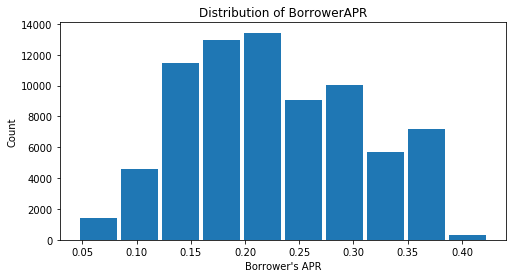

```python
# Ploting borrower APR distribution using histogram chart plotted with matplotlib .hist() plot function
plt.figure(figsize = (8, 4))

plt.hist(data = PLoan_df_clean, x = 'BorrowerAPR', rwidth = 0.9);
plt.xlabel('Borrower\'s APR')
plt.ylabel('Count')
plt.title("Distribution of BorrowerAPR")
```

#### ProsperScore Variable Distribution

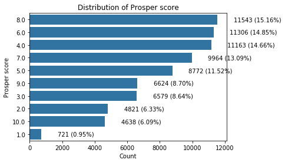

```python
#ploting distribution of prosper score using bar chart

total_listings = PLoan_df_clean.shape[0]

# Ploting the prosperscore on a Horizontal bar chart
base_color = sb.color_palette()[0]
Prosper_score = PLoan_df_clean.ProsperScore.value_counts().index
sb.countplot(data = PLoan_df_clean, y = 'ProsperScore', color = base_color
              , order = Prosper_score);
plt.xlabel('Count')
plt.ylabel('Prosper score')
plt.title("Distribution of Prosper score")

# retrieve locations of yticks
locs = plt.yticks()[0]

# number of listings in descending order for each score
score_counts = PLoan_df_clean.ProsperScore.value_counts()

for loc, scores in zip(locs, Prosper_score):
    # number of listings for the given Prosper score
    score_count = score_counts[scores]

    # calculate the proportion of the score in % [format: score count (proportion)]
    scores_proportion = '{} ({:0.2f}%)'.format(score_count, 100*score_count/total_listings)

    # annotate the proportion of the state to the right of its corresponding bar
    plt.text(x = score_count + 1000, y = loc, s = scores_proportion, va = 'center', color = 'black', fontsize = 10)
```

From the Bar Chart above majority of the prosper borrowers scored 8 (which is low risk) with 15.16% proportion and 1 (very high risk) was the least in the rating with 0.95% proportion. Scores 6,7,8, 9 and 10 which I recognised as low risk rating take highest proportion (57.89%) of the prosper borrowers. This indicate that prosper borrowers generally have low risk arting.

### Visualization of Numeric Variables: EmploymentStatusDuration, LoanOriginalAmount, MonthlyLoanPayment, DebtToIncomeRatio, StatedMonthlyIncome & AvailableBankcardCredit

#### Employment Status Duration Distribution

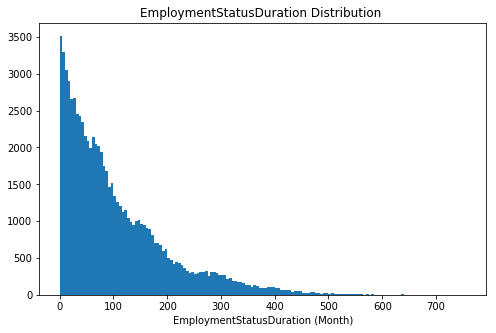

```python
#Ploting EmploymentStatusDuration distribution using matplotlib hist() plot function

# I start with a standard-scaled plot
Ploan_df =PLoan_df_clean[np.isfinite(PLoan_df_clean['EmploymentStatusDuration'])]
binsize = 5
bins = np.arange(0, PLoan_df_clean['EmploymentStatusDuration'].max()+binsize, binsize)

plt.figure(figsize=[8, 5])
plt.hist(data = PLoan_df_clean, x = 'EmploymentStatusDuration', bins = bins)
plt.xlabel('EmploymentStatusDuration (Month)')
plt.title("EmploymentStatusDuration Distribution ")
plt.show()
```

The histogram shown above illustrate that the distribution of the duration of the borrowers' employment statuses when their listings were created in Prosper is right-skewed. The number of borrowers exponentially decreased with longer duration of employment status. The majority of the borrowers' employment status lasted between 0 to less than 100 months. This range includes the center of the distribution observed at approximately 75 months.

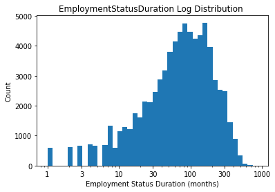

```python
# distribution of employment status duration in log scale

log_data = np.log10( PLoan_df_clean.query('EmploymentStatusDuration > 0').EmploymentStatusDuration)
# bin edges for log scale
log_binsize = 0.07 # selected after visually inspecting the distribution of the log scale data
log_bins = 10 ** np.arange(0, log_data.max()+log_binsize, log_binsize)

# histogram with x-axis in log scale
plt.hist(x = PLoan_df_clean.EmploymentStatusDuration, bins = log_bins)
plt.xscale('log')

# custom labels for xticks
locs = [1, 3, 10, 30, 100, 300, 1000]
labels = ['{}'.format(loc) for loc in locs]
plt.xticks(locs, labels)

plt.xlabel('Employment Status Duration (months)')
plt.title("EmploymentStatusDuration Log Distribution ")
plt.ylabel('Count');
```

Applying a log transformation to the duration of employment status reduces the degree of right-skewed distribution. However, because significantly small number of borrowers maintained their employment statuses for more than 300 months or 25 years, the distribution of the log-transformed data appear to be slightly left-skewed than normal.

#### Distribution of Loan Original Amount

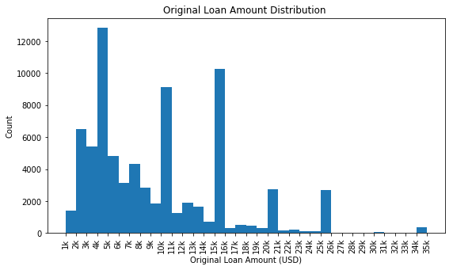

```python
#ploting distribution Loan Original Amount using matplotlib hist() plot function
plt.figure(figsize = (9, 5))

bins = np.arange(PLoan_df_clean.LoanOriginalAmount.min(), 35000+1000, 1000)
plt.hist(data = PLoan_df_clean, x = 'LoanOriginalAmount', bins = bins)

# specify and set locations and labels for xticks
locs = bins
labels = ['{:.0f}k'.format(bin_edge/1000) for bin_edge in bins]
plt.xticks(locs, labels)

plt.xlabel('Original Loan Amount (USD)')
plt.ylabel('Count');
plt.title("Original Loan Amount Distribution ")
plt.xticks(rotation=90)
```

#### Monthly Loan Payment

```
Text(0.5,1,'Monthly Loan Paymentt Distribution ')
```

[figure not shown]

```python
# monthly incomes for approximately 1.5 times the IQR below and above IQR
plt.figure(figsize = (9, 5))

bins = np.arange(0, 1500+100, 100)
plt.hist(data = PLoan_df_clean, x = 'MonthlyLoanPayment', bins = bins,  rwidth =0.8)

# # specify and set locations and labels for xticks
locs = bins
labels = ['{:.0f}k'.format(bin_edge/100) for bin_edge in bins]
plt.xticks(locs, labels)

plt.xlabel('MonthlyLoanPayment (USD)')
plt.ylabel('Count');
plt.title("Monthly Loan Paymentt Distribution ")
```

#### Debt To Income Ratio Distribution

```
Text(0.5,1,'Debt To Income Ratio Distribution ')
```

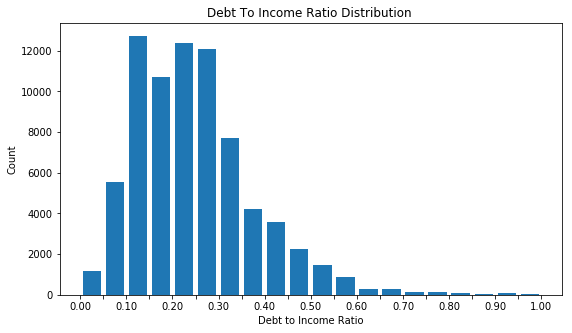

```python
# debt to income ratios for approximately
plt.figure(figsize = (9, 5))

bins = np.arange(0, 1+0.05, 0.05)
plt.hist(data = PLoan_df_clean, x = 'DebtToIncomeRatio', bins = bins, rwidth =0.8)

# specifying and setting  locations and labels for xticks
locs = bins
labels = []
for i, bin_edge in enumerate(bins):
    if i % 2 == 0: # for every two bin edges
        labels.append('{:0.2f}'.format(bin_edge))
    else:
        labels.append('')
plt.xticks(locs, labels)

plt.xlabel('Debt to Income Ratio')
plt.ylabel('Count');
plt.title("Debt To Income Ratio Distribution ")
```

The distribution of the debt to income ratios ranging from 0 to 1 was right-skewed with most of the listings observed for ratios from 0.10 to 0.15. Because approximately half of all listings were for consolidating debt and almost all listings were for borrowers with debt to income ratios less than 1, borrowers who sought to consolidate debts must have applied for loans in Prosper before their debt exceeded their income.

#### Stated Monthly Income

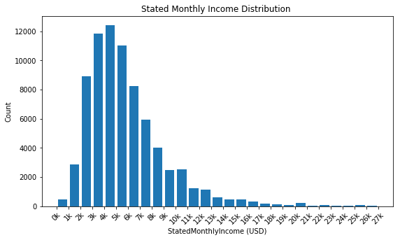

```python
# monthly incomes distribution using hist() plot function
plt.figure(figsize = (9, 5))

bins = np.arange(0, 27000+1000, 1000)
plt.hist(data = PLoan_df_clean, x = 'StatedMonthlyIncome', bins = bins, rwidth =0.8)

# # specifying and setting locations and labels for xticks
locs = bins
labels = ['{:.0f}k'.format(bin_edge/1000) for bin_edge in bins]
plt.xticks(locs, labels)

plt.xlabel('StatedMonthlyIncome (USD)')
plt.ylabel('Count');
plt.title("Stated Monthly Income Distribution ")
plt.xticks(rotation=45)
```

The distribution of the borrowers' stated monthly incomes was right-skewed. Bulk of the listings were for borrowers with monthly incomes between \$2,000 and \$6,000. The center of the distribution hints a possiblity of a vicious cycle in which individuals with relatively low incomes seek for loans which in turn may put them in a worse financial position.

#### Available Bank card Credit

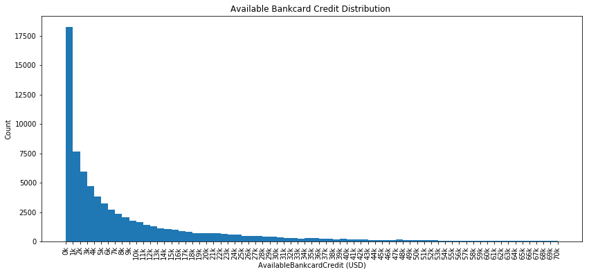

```python
# ploting Available Bank card Credit using hist() plot function
plt.figure(figsize = (14, 6))

bins = np.arange(0, 70000+1000, 1000)
plt.hist(data = PLoan_df_clean, x = 'AvailableBankcardCredit', bins = bins)

# # specifying and setting locations and labels for xticks
locs = bins
labels = ['{:.0f}k'.format(bin_edge/1000) for bin_edge in bins]
plt.xticks(locs, labels)

plt.xlabel('AvailableBankcardCredit (USD)')
plt.ylabel('Count');
plt.title("Available Bankcard Credit Distribution ")
plt.xticks(rotation=90)
```

### Visualization of categorical variables: LoanStatus, CreditScore, Loan Terms and Employment status

#### Prospers borrowers loan statues

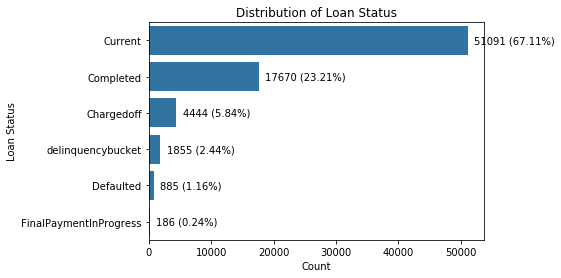

```python
# Ploting the LoanStatus on a Horizontal bar chart
base_color = sb.color_palette()[0]
Loan_status = PLoan_df_clean.LoanStatus.value_counts().index
sb.countplot(data = PLoan_df_clean, y = 'LoanStatus', color = base_color
              , order = Loan_status);
plt.xlabel('Count')
plt.ylabel('Loan Status')
plt.title("Distribution of Loan Status")

# retrieving locations of yticks
locs = plt.yticks()[0]

# number of listings in descending order for each status
status_counts = PLoan_df_clean.LoanStatus.value_counts()

for loc, status in zip(locs, Loan_status):
    # number of listings for the given loan status
    status_count = status_counts[status]

    # calculate the proportion of the status in % [format: status count (proportion)]
    status_proportion = '{} ({:0.2f}%)'.format(status_count, 100*status_count/total_listings)

    # annotate the proportion of the state to the right of its corresponding bar
    plt.text(x = status_count + 1000, y = loc, s = status_proportion, va = 'center', color = 'black', fontsize = 10)
```

Exploring the Loan status, Majority of proper loan are still active at the time of the listing, majority which represent 67.11% of the dataset. 23.21% have completed their loan payment and there were very few borrowers that defaulted this represent 1.16% of the dataset.

#### Credit Score Distribution

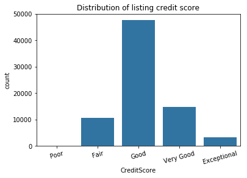

```python
# Ploting creditscore with bar chart

fig, ax = plt.subplots(nrows=1, figsize = [6,4])

default_color = sb.color_palette()[0]
sb.countplot(data = PLoan_df_clean, x = 'CreditScore', color = default_color)

plt.xticks(rotation=15)
plt.title("Distribution of listing credit score")
plt.show()
```

Majority of the prosper borrowers credit scores were good this rating between (670–739), this was followed by Very Good rating. We have zero(0) Rating range between 300–579 which are poor rating. This shows that prosper borrowers must have at least fair rating before they could be able to secure loan with prosper.

#### Distribution of Loan Terms

[figure not shown]

```python
# Ploting the Term on a Horizontal bar chart
base_color = sb.color_palette()[0]
term = PLoan_df_clean.Term.value_counts().index
sb.countplot(data = PLoan_df_clean, y = 'Term', color = base_color
              , order = term);
plt.xlabel('Count')
plt.ylabel('Term (Month)')
plt.title("Loan Terms")

# retrieving locations of yticks
locs = plt.yticks()[0]

# number of listings in descending order for each term
Term_counts = PLoan_df_clean.Term.value_counts()

for loc, terms in zip(locs, term):

    # number of listings for the given term
    term_count = Term_counts[terms]

    # calculate the proportion of the term in % [format: term count (proportion)]
    term_proportion = '{} ({:0.2f}%)'.format(status_count, 100*term_count/total_listings)

    # annotate the proportion of the state to the right of its corresponding bar
    plt.text(x = term_count + 1000, y = loc, s = term_proportion, va = 'center', color = 'black', fontsize = 10)
```

From the Bar Plot above it observed that proper gives loan for all the three terms 12, 36 and 60 months. But majority of loans were given on 36 month terms this represent 68.27% of the dataset, this was followed by 60 months term which is 29.88%. Also, proper have some loan given out on 12 month term which are 1.86% of the dataset.

#### Employment status Distribution

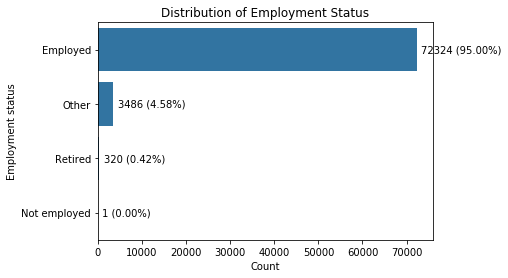

```python
# Ploting the EmploymentStatus on a Horizontal bar chart
base_color = sb.color_palette()[0]
Emp_status = PLoan_df_clean.EmploymentStatus.value_counts().index
sb.countplot(data = PLoan_df_clean, y = 'EmploymentStatus', color = base_color
              , order = Emp_status);
plt.xlabel('Count')
plt.ylabel('Employment status')
plt.title("Distribution of Employment Status")

# retrieving locations of yticks
locs = plt.yticks()[0]

# number of listings in descending order for each status
status_counts = PLoan_df_clean.EmploymentStatus.value_counts()

for loc, status in zip(locs, Emp_status):
    # number of listings for the given emp status
    status_count = status_counts[status]

    # calculate the proportion of the status in % [format: status count (proportion)]
    status_proportion = '{} ({:0.2f}%)'.format(status_count, 100*status_count/total_listings)

    # annotate the proportion of the state to the right of its corresponding bar
    plt.text(x = status_count + 1000, y = loc, s = status_proportion, va = 'center', color = 'black', fontsize = 10)
```

The majority of the prosper borrowers are "Employed" this represent 95.0%.95% includes all the employed borrowers, Full-time, Self-employed and even Part-time. Borrowers who were either not employed or retired at the time their listings were created were less than 1% of all the borrowers in Prosper.

### Discuss the distribution(s) of your variable(s) of interest. Were there any unusual points? Did you need to perform any transformations?

> The Borrowers APR variable is a numeric variable that was perfectly distributed and show an accurate picture of the dataset while plotting with histogram chart. The histogram was ditributed well through divided binsize from 0.05 to o.4 borrowers ARR.

### Of the features you investigated, were there any unusual distributions? Did you perform any operations on the data to tidy, adjust, or change the form of the data? If so, why did you do this?

> When investigating EmploymentStatusDuration variables, a number of outlier points were identified and the plot was right-skewed, it was futher investiagated with the use of log transformation which reduces the degree of skewed. this was done to further investigate and understand the variable.

## Bivariate Exploration

#### Looking at the pairwise correlations present between features in the dataset.

```python
#Assigning variables
numeric_vars = ['BorrowerAPR', 'ProsperScore','DebtToIncomeRatio', 'EmploymentStatusDuration', 'AvailableBankcardCredit', 'LoanOriginalAmount', 'StatedMonthlyIncome','MonthlyLoanPayment']
categoric_vars = ['CreditScore','LoanStatus','EmploymentStatus', 'Term']
```

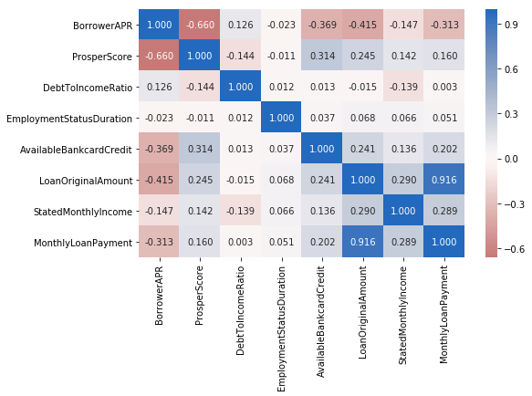

```python
# correlation plot
plt.figure(figsize = [8, 5])
sb.heatmap(PLoan_df_clean[numeric_vars].corr(), annot = True, fmt = '.3f',
           cmap = 'vlag_r', center = 0)
plt.show()
```

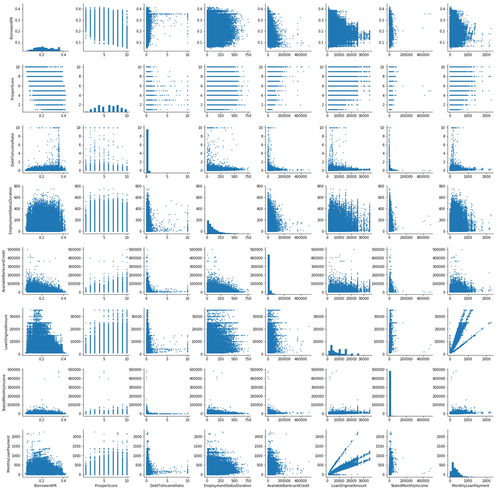

```python
# matrix of scatter plots for APR vs. discrete data
g = sb.PairGrid(data = PLoan_df_clean, vars = numeric_vars)
g = g.map_diag(plt.hist, bins = 20);
g.map_offdiag(plt.scatter, s = 2);
```

Generally, a very low/negative corelation was noticed between all the Numeric variables the the dataset. The corelation between Borrowers APR and ProsperScore was negative(-0.660), likewsise with the AvailableBankcardCredit, StatedMonthlyIncome, LoanOriginalAmount and EmploymentStatusDuration. Corelation between BorrowerAPR and DebtToIncomeRatio was a very low positive corelation 0.126.

As expected there was a very strong corelation between LoanOriginalAmount and MonthlyLoanPayment as the loan original amount determined the amount paid monthly. There was a fair positive corelation between ProsperScore amount and Available Bank card Credit and loan original amount.

#### Looking at the effect of prosper score on the Borrowers APR.

```
Text(0.5,1,'Prosper Score vs Borrower APR')
```

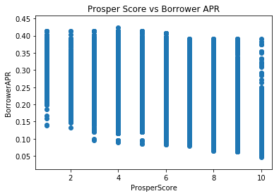

```python
# Scatter plot
plt.scatter(data = PLoan_df_clean, x = 'ProsperScore', y = 'BorrowerAPR'),
plt.xlabel('ProsperScore')
plt.ylabel('BorrowerAPR')
plt.title("Prosper Score vs Borrower APR")
```

Inconcating Transparency and jiteer to Exploration of relationship between Prosper Score and Borrower APR. also using heat map to show the relationship

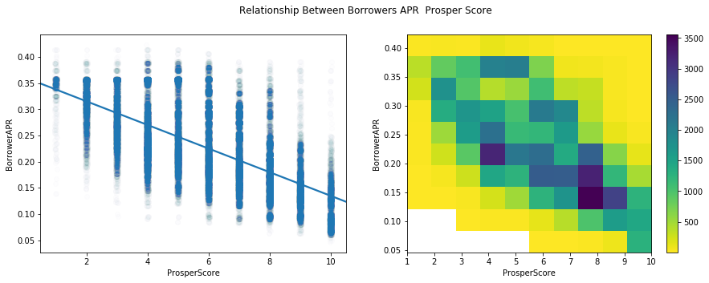

```python
# Define the figure size
plt.figure(figsize = [15, 5])

#PLOT ON LEFT
#Ploting scatttere graph with both Jitter and Transparency to corect Overplotting observed.
plt.subplot(1, 2, 1)
sb.regplot(data = PLoan_df_clean, x = 'ProsperScore', y = 'BorrowerAPR', truncate=False, x_jitter=0.04, scatter_kws={'alpha':0.1/15});

#PLOT ON RIGHT
plt.subplot(1, 2, 2)
#Heat Map shows relationship between prosper score on the Borrowers APR
#Used cmin to set a minimum bound of counts
# Use cmap to reverse the color map.
plt.hist2d(data= PLoan_df_clean, x= 'ProsperScore', y= 'BorrowerAPR', cmin=0.04, cmap='viridis_r')
plt.colorbar()
plt.xlabel('ProsperScore')
plt.ylabel('BorrowerAPR');

plt.suptitle('Relationship Between Borrowers APR  Prosper Score');
```

Generally; Higher Prosper Score leads to Lower ARP, the lower the APR the lower the risk

#### Looking at the effect of Loan Original Amount, Available Bankcard Credit and Debt To Income Ratio on Borrower APR

```
Text(0.5,0.98,'Matrix Plot of BorrowerAPR, LoanOriginalAmount, AvailableBankcardCredit and DebtToIncomeRatio')
```

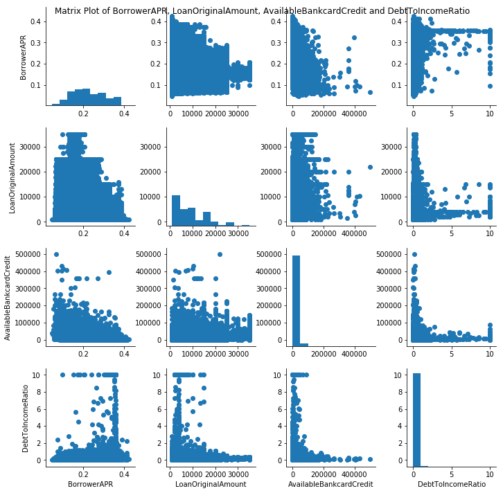

```python
Num_vars = ['BorrowerAPR','LoanOriginalAmount', 'AvailableBankcardCredit', 'DebtToIncomeRatio']

# creation of plot Matrix with Seaborn's PairGrid class
g = sb.PairGrid(data = PLoan_df_clean, vars = Num_vars)
g.map_diag(plt.hist)
g.map_offdiag(plt.scatter)

g.fig.suptitle('Matrix Plot of BorrowerAPR, LoanOriginalAmount, AvailableBankcardCredit and DebtToIncomeRatio')
```

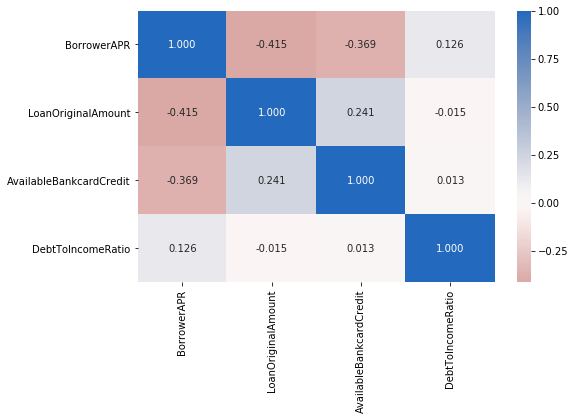

```python
# correlation plot
plt.figure(figsize = [8, 5])
sb.heatmap(PLoan_df_clean[Num_vars].corr(), annot = True, fmt = '.3f',
           cmap = 'vlag_r', center = 0)
plt.show()
```

From the univariate exploration, we have a good undertanding regarding the range of values we can expect. There was a negative correlation betweent loan original amount and available bank card credit with the borrowers APR, this shows that the higher the Borrowers APR the lower the loan original amount and the lower the availabel bank card credit. There doesn't appear to be any strong correlation between borrowers APR and the DebtToIncomeRatio. We may have to investigate further by querying select categories of listing.

There doesn't appear to be any strong correlation between any of the other numeric variables either.

You may intuitively expect the borrowers APR be majorly determined by high debt to income ratio and AvailableBankcardCredit- but that doesn't seem to be the case.

#### BorrowerAPR and ProsperScore relationship with categorical_variables

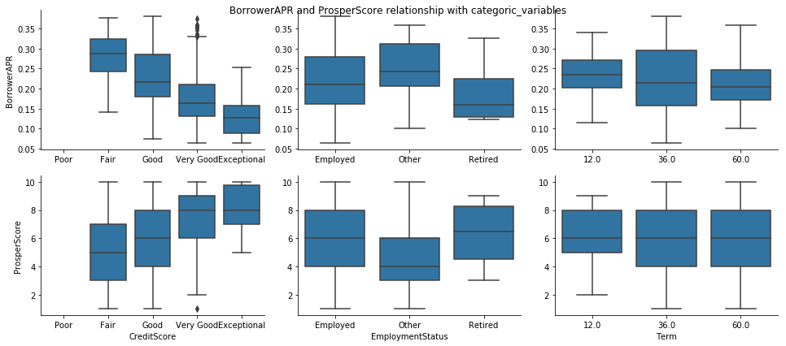

```python
categoric_var= ['CreditScore','EmploymentStatus', 'Term']

# plot matrix of numeric features against categorical features.
# can use a larger sample since there are fewer plots and they're simpler in nature.

samples = np.random.choice(PLoan_df_clean.shape[0], 2000, replace = False)
PLoan_df_clean_samp = PLoan_df_clean.loc[samples,:]

def boxgrid(x, y, **kwargs):
    """ Quick hack for creating box plots with seaborn's PairGrid. """
    default_color = sb.color_palette()[0]
    sb.boxplot(x, y, color = default_color)

plt.figure(figsize = [15, 15])
g = sb.PairGrid(data = PLoan_df_clean_samp, y_vars = ['BorrowerAPR', 'ProsperScore'], x_vars = categoric_var,
                size = 3, aspect = 1.5)
g.map(boxgrid)
g.fig.suptitle('BorrowerAPR and ProsperScore relationship with categoric_variables')
plt.show();
```

Based on the six sets of box plots, one set for each quantitative variable and one box plot row for BorrowerAPR and ProsperScore, the bivariate relationships of BorrowerAPR and ProsperScore with Employment Status, Credit Score and Term.

From these boxplot, we're able to clearly see that as the borrowers APR decreasing, the median credit score increase. Also, as the Prosper score increase as credit score increase. Borrower with a good credit score gets lower interest rate and borrower with a good credit score has low risk of not payback.

#### Effect of Borrower ARP on Loan Outcome Status

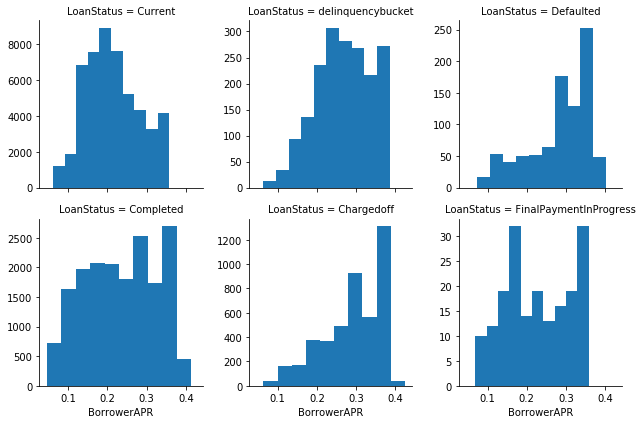

```python
#showing effect of Borrower APR on Loan outcome status with FacetGrid
g = sb.FacetGrid(data = PLoan_df_clean, col = 'LoanStatus', col_wrap=3, sharey=False)
g.map(plt.hist, 'BorrowerAPR');
```

```
Text(0.5,1,'Prosper Score vs Borrower APR')
```

[figure not shown]

```python
# Violin plot showing relationship between borrowers APR and Loanstatus
plt.figure(figsize = [10, 5])
base_color = sb.color_palette()[0]

ax1 = sb.violinplot(data=PLoan_df_clean, x='LoanStatus', y='BorrowerAPR', color=base_color)
plt.xticks(rotation=15);
plt.title("Prosper Score vs Borrower APR")
```

One of the things about the relationship between LoanStatus categories is that it isn't consistent. current status tend to have lower BorrowersAPR than completed and full payment progress. Defaulted and chargeoff have higher borowerAPR when compare to delinquencybucket. cancelled loan status is insignificant in the dataset to be display.

#### Effect of Loan Term and Employment status on Original loan amount

```
Text(0.5,1,'Distribution of Loan Term, Employment status and Original loan amount')
```

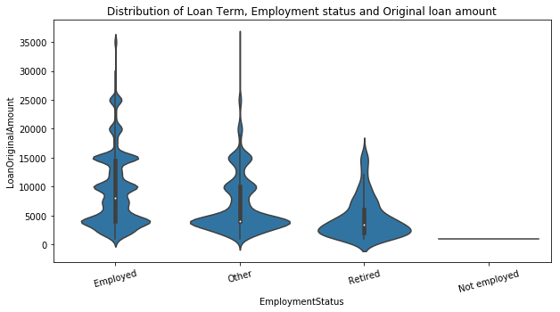

```python
# Violin plot relationship between Employment and LoanOriginalAmount
plt.figure(figsize = [10, 5])
base_color = sb.color_palette()[0]

ax1 = sb.violinplot(data=PLoan_df_clean, x='EmploymentStatus', y='LoanOriginalAmount', color=base_color)
plt.xticks(rotation=15);
plt.title("Distribution of Loan Term, Employment status and Original loan amount")
```

People employed take loans of Higher Amounts when compared to people who are Retired or have other employment status. The median of employes 5000 higher to retired and unemployed.

Let now look at Loan Original Amount vs Term, to see how loan term determine the amount accessable to the borrowers

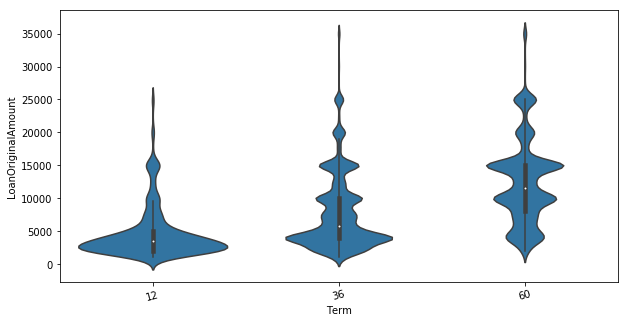

```python
# Violin plot relationship between Term and LoanOriginalAmount
plt.figure(figsize = [10, 5])
base_color = sb.color_palette()[0]

ax1 = sb.violinplot(data=PLoan_df_clean, x='Term', y='LoanOriginalAmount', color=base_color)
plt.xticks(rotation=15);
```

### Talk about some of the relationships you observed in this part of the investigation. How did the feature(s) of interest vary with other features in the dataset?

> The BorrowersAPR is Negatively Correlated with Prosper Score which is the borrowers risk rating, even before transforming the features. Due to the discrete nature of the proper score, when it was ploted against Borrowers APR an overplotting was noticed.  
> An approximately linear relationship was observed when borrowers APR was ploted against Prospers score with Trasparency and jitter. The scatterplot that came out of this, also shows clearly the higher Prosper Score leads to Lower ARP, the lower the APR the lower the risk.

> There was a negative correlation notice between borrowers APR and numeric variables, loan original amount and available bank card credit. This shows that the higher the Borrowers APR the lower the loan original amount and the lower the available bank card credit. it doesn't appear to be any strong correlation between borrowersAPR and the DebtToIncomeRatio.

> There was also an interesting relationship observed between borrowers APR and the categorical features. we're able to clearly see that as the borrowers APR decreasing, the median credit score increase, this indicated that people with a good credit score gets lower interest rate. Also, other employment status have higher BorrowerAPR when compired to both employed and retired and borrowersAPR relationship with Loan Term shows that Borrowers APR decreases as the loan terms increases. Borrowers with 60 month loan term have high chances of having low interest rate.

### Did you observe any interesting relationships between the other features (not the main feature(s) of interest)?

> The observed relationship between Employemnt statues and Loan Original amount shows that Employed people take loans of Higher Amounts when compared to people who are Retired. Loan term inrelation to Loan Original Amount shows that Loan Original amount increase as the Term increase. 60 month Term has the higher loan amount when compare to 36 and 12 months.

## Multivariate Exploration

#### Exploring relationship between ProsperScore and BorrowerAPR with Credit score and loan status

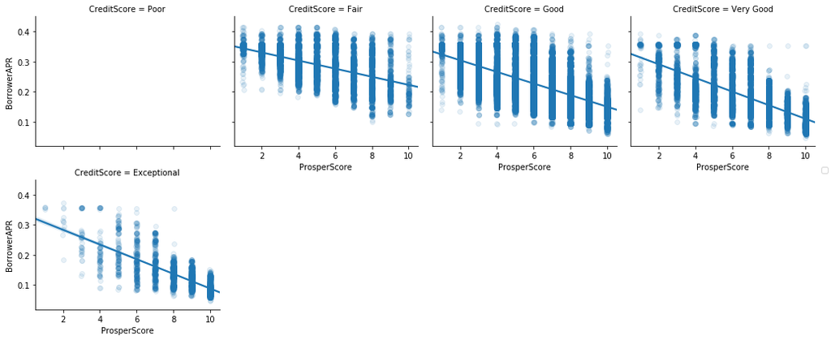

```python
# Credit score effect on relationship of APR and ProsperScore with FacetGrid
g=sb.FacetGrid(data=PLoan_df_clean, aspect=1.2, col='CreditScore', col_wrap=4)
g.map(sb.regplot, 'ProsperScore', 'BorrowerAPR', x_jitter=0.04, scatter_kws={'alpha': 0.1});
g.add_legend();
```

The Borrowers APR decreases with better credit score. Listing with Exceptional credit score are few compared to other credit score but have chances of accessing loan with lower interest rate.

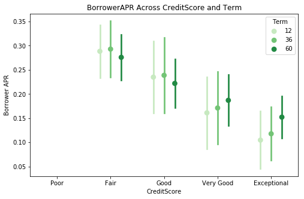

```python
fig = plt.figure(figsize = [8,5])
ax = sb.pointplot(data = PLoan_df_clean, x = 'CreditScore', y = 'BorrowerAPR', hue = 'Term',
           palette = 'Greens', linestyles = '', dodge = 0.4, ci='sd')
plt.title('BorrowerAPR Across CreditScore and Term')
plt.ylabel('Borrower APR')
ax.set_yticklabels([],minor = True);
```

#### Rid scatter plots Exploring BorrowerAPR, ProsperScore relationship with CreditScore and Term

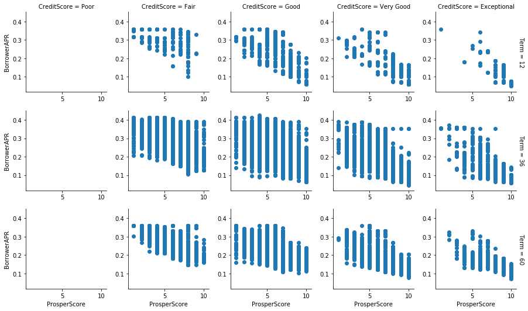

```python
g = sb.FacetGrid(data = PLoan_df_clean, col = 'CreditScore', row = 'Term', size = 2.5,
                margin_titles = True)
g.map(plt.scatter, 'ProsperScore', 'BorrowerAPR')
```

Insights are difficult with these scatterplots. There do not seem to be any difference in how the data is related based on individual categories of CreditScore or Term

#### Let now exploy BorrowerAPR, ProsperScore relationship with LoanStatus and Term with Rid scatter plots

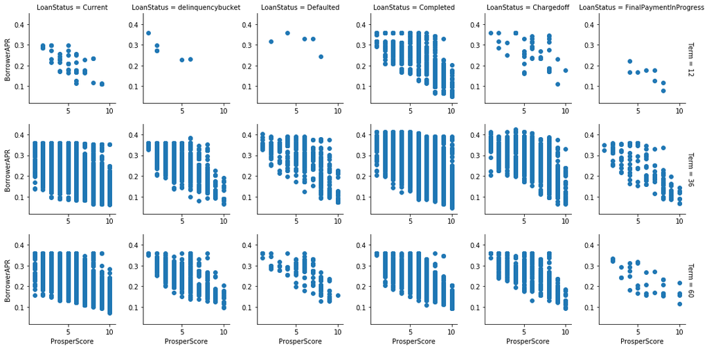

```python
g = sb.FacetGrid(data = PLoan_df_clean, col = 'LoanStatus', row = 'Term', size = 2.5,
                margin_titles = True)
g.map(plt.scatter, 'ProsperScore', 'BorrowerAPR')
```

There do not seem to be any difference in how the data is related based on individual categories of LoanStatus or Term. Negative correlation bertween borrowersAPR and Propers score are till visible with loanstatus and Term categories. Majority of listing defaulters are 36 month loan term, not suprising as majority of listings have 36 month loan term.

#### Looking at the relationship between LoanStatus, LoanOriginalAmount and Term

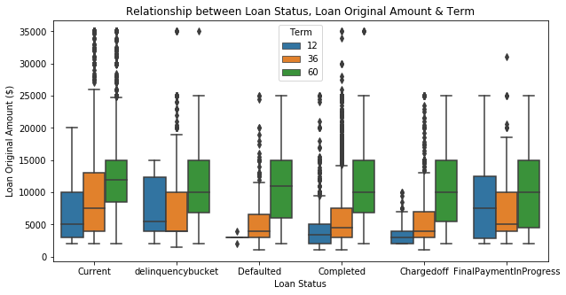

```python
plt.figure(figsize=[10,5])
sb.boxplot(data=PLoan_df_clean,x="LoanStatus",y="LoanOriginalAmount",hue="Term");
plt.xlabel("Loan Status");
plt.ylabel("Loan Original Amount ($)");
plt.title("Relationship between Loan Status, Loan Original Amount & Term");
```

With Boxplot, exploration shows that current loan amount increase with loan terms. Amount defaulted with 60 term is higher when compared with amount completed on 60 Terms.

### Talk about some of the relationships you observed in this part of the investigation. Were there features that strengthened each other in terms of looking at your feature(s) of interest?

> Exploring BorrowerAPR and ProsperScore relationship with LoanStatus and Term with Rid scatter plots give us a view that majority of listing defaulters are 36 month loan term, although not suprising as majority of listings have 36 month loan term. I later viewed the relationship with loan amount and see that Amount defaulted with 60 term is higher when compared with amount completed On 60 Term.

### Were there any interesting or surprising interactions between features?

> It was suprising when i explore the relationship between ProsperScore and BorrowerAPR with Credit score and loan status and i found out that Borrowers APR decreases with better credit score.

## Conclusions

My exploration analysis of prosper loan dataset was stated by gathering of data which was downloaded directly from Udacity website and i furthered by assessing the data visually and programatically in which some quality and tidiness issues were noticed and documented. After assessment i proceed to cleaning of the identified issues before i started my visualization exploration.

In the exploration, I found that there was a strong relationship between the Borrowers APR and prospers score which is the ranking of risk of the listing, with modifying effects it was clearly showed that as ARP is decreasing the prosper score increased. Higher Prosper Score leads to Lower ARP, the lower the APR the lower the risk. Exploring borrowers APR with other numeric variables shows that there was negative relationship between borrowers APR and loan original amount and available bank card credit, this shows that the higher the Borrowers APR the lower the loan original amount and the lower the available bank card credit.